# R Notebook

# Does the proportion of books in the Goodreads database that lack text reviews differ significantly from 7%?

alpha = 0.05 H0: prop books lack text = 0.07 Ha: prop books lack text != 0.07

```r
library(tidyverse)
library(janitor)
library(infer)
```

```r
books <- read_csv("data/books.csv") %>% clean_names()
```

# Cleaning

```r
books_tidy_2020 <- books %>%
  filter(!is.na(average_rating)) %>%
  rename(num_pages = number_num_pages)
```

# Find proportion of books with no text reviews

```r
observed_stat <- books_tidy_2020 %>%
  group_by(text_reviews_count) %>%
  summarise(prop = n()/nrow(books_tidy_2020)) %>%
  filter(text_reviews_count == 0) %>%
  pull(prop)
```

Calculate prop using infer

```r
infer_stat <- books_tidy_prop %>%
  specify(response = text_reviews_flag,
          success = "no_text_review") %>%
  calculate(stat = "prop")
```

# Create a binary variable

| book_id | title | authors | average_rating | isbn | isbn13 | language_code | num_pages | ratings_count | text_reviews_count | text_reviews_flag |
| --- | --- | --- | --- | --- | --- | --- | --- | --- | --- | --- |
| 1 | Harry Potter and the Half-Blood Prince (Harry Potter #6) | J.K. Rowling-Mary GrandPré | 4.56 | 0439785960 | 9780439785969 | eng | 652 | 1944099 | 26249 | text_review |
| 2 | Harry Potter and the Order of the Phoenix (Harry Potter #5) | J.K. Rowling-Mary GrandPré | 4.49 | 0439358078 | 9780439358071 | eng | 870 | 1996446 | 27613 | text_review |
| 3 | Harry Potter and the Sorcerer's Stone (Harry Potter #1) | J.K. Rowling-Mary GrandPré | 4.47 | 0439554934 | 9780439554930 | eng | 320 | 5629932 | 70390 | text_review |
| 4 | Harry Potter and the Chamber of Secrets (Harry Potter #2) | J.K. Rowling | 4.41 | 0439554896 | 9780439554893 | eng | 352 | 6267 | 272 | text_review |
| 5 | Harry Potter and the Prisoner of Azkaban (Harry Potter #3) | J.K. Rowling-Mary GrandPré | 4.55 | 043965548X | 9780439655484 | eng | 435 | 2149872 | 33964 | text_review |
| 8 | Harry Potter Boxed Set Books 1-5 (Harry Potter #1-5) | J.K. Rowling-Mary GrandPré | 4.78 | 0439682584 | 9780439682589 | eng | 2690 | 38872 | 154 | text_review |
| 9 | Unauthorized Harry Potter Book Seven News: "Half-Blood Prince" Analysis and Speculation | W. Frederick Zimmerman | 3.69 | 0976540606 | 9780976540601 | en-US | 152 | 18 | 1 | text_review |
| 10 | Harry Potter Collection (Harry Potter #1-6) | J.K. Rowling | 4.73 | 0439827604 | 9780439827607 | eng | 3342 | 27410 | 820 | text_review |
| 12 | The Ultimate Hitchhiker's Guide: Five Complete Novels and One Story (Hitchhiker's Guide to the Galaxy #1-5) | Douglas Adams | 4.38 | 0517226952 | 9780517226957 | eng | 815 | 3602 | 258 | text_review |
| 13 | The Ultimate Hitchhiker's Guide to the Galaxy | Douglas Adams | 4.38 | 0345453743 | 9780345453747 | eng | 815 | 240189 | 3954 | text_review |

[output cut: 990 more lines]

# Generate a null distribution

# Visualise null distribution and observed statistics

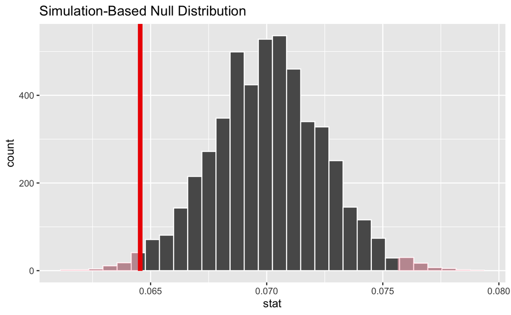

# Calculate p value

| p_value |
| --- |
| 0.026 |

# Task

Task - 15 mins Let’s say you work for a publishing company and you want to use the Goodreads database to provide insight for future investment. Your CEO has decided they want to invest in French language books, if there is compelling evidence that there is a lack of such books in the market. Based on their experience of the industry, they have decided that if the proportion of books published in French is less than 1.5% then they will invest in publishing more. The hypothesis test corresponding to this business question is H0: π French = 0.015 Ha: π French < 0.015 Let’s say answering this question is very important to the business because it will be used to justify investment, so we want to be ‘stricter’ and perform a more ‘conservative’ test. This is because, if we reject H0, we will be investing money, and so it will be more costly to make a type-I error (a false positive, i.e. we conclude that the proportion of books that are French is less than 1.5% even though it is not in reality), than a type-II error (a false negative). We would do this by decreasing our significance level α for the test. By decreasing α we reject H0 less often and need to have very strong evidence to do so. So, we will test this hypothesis at a significance level of α=0.01.

# Is the proportion of books written in French less than 1.5%

H0: prop_in_french = 0.015 Ha: prop_in_french < 0.015 alpha = 0.01

# Get observed statistic

```r
nrow(books_tidy_2020$language_code == "fre")
```

# Get null distribution

```r
null_dist_french_1.5 <- books_tidy_2020 %>%
  mutate(in_french = if_else(language_code == "fre", "french", "not_french")) %>%
  specify(response = in_french, success = "french") %>%
  hypothesise(null = "point", p = 0.015) %>%
  generate(reps = 5000, type = "simulate") %>%
  calculate(stat = "prop")
```

# Visualise null distribution and observed stat

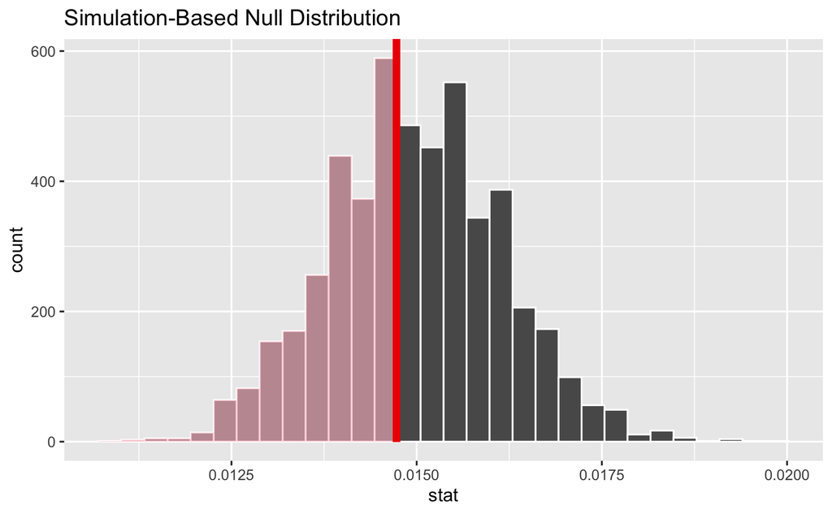

distribution not very very normal…

# Calculate p value

| p_value |
| --- |
| 0.431 |

If null hypothesis were true, that percentage of books written in French = 1.5%, then I would get this distribution if I were able to take 5000 samples of 10999 observations of all books. If this were true, I could still get a value of 0.0147 (as observed in my sample) or less 43% of the time. This means that the proportion of books written in French in this sample does not indicate that in reality, H0 is not true. Our sample proportion is very possible if the percent of books written in French is 1.5%.